# Hands on GWAS in R

Waseem Hussain

07 October, 2022

**Load the required libraries**

# 1 Data Description

**Description of the data**

### 1.0.1 Read the phenotypic data

```r
> # Here we will upload the phenotypic data saved in directory.
>   rm(list=ls())
>   setwd("~/Documents/GitHub/RforPlantBreeding/GWAS_in_R")
>   rice.pheno <- read.table("./datafiles/RiceDiversity_44K_Phenotypes_34traits_PLINK.txt",
+                          header=TRUE, stringsAsFactors = FALSE, sep = "\t")
> # Select the appropriate columns
>   rice.pheno<-rice.pheno[, c(2,3,14)]
> # Now paste NSFTV_ to each genotype name
>   rice.pheno$NSFTVID<-paste0("NSFTV_", rice.pheno$NSFTVID)
> # Now drop the ones wih no data
>   rice.pheno<-na.omit(rice.pheno)
> # check dimensions of data
>   dim(rice.pheno)
```

```
[1] 373   3
```

### 1.0.2 Read the marker data

**Description data**

- We will upload the marker data files saved in working directory in datafiles folder.
- The data used here was downloaded from http://ricediversity.org/data/sets/44kgwas/.
- When we unzip the file downloaded from link above, you will find three files **.fam** (contains names about the acessions/genotypes), **.map** (contains map information including chromosome, position and marker name) and **.ped** (conatins the marker allele data in 0, 1, 2, and 3 format; 2 represents missing data). The files are plink converted files.
- 1 represents heterozygous, 0 and 3 represents homozygous for major and minor allele.
- We will read all the three data files. For reading **.ped** we will use BGLR R package.
- We will recode the marker data to 0 (homozygous, major allele), 1 (Heterozygous) and 2 (homozygous, minor allele) format and missing as NA.
- Finally, we will convert the marker data into matrix and transpose it

```r
> # Read the .ped file having genotype information
>   Geno<-read_ped("./datafiles/sativas413.ped")
>   p=Geno$p
>   n=Geno$n
>   Geno=Geno$x
>
> # Now load .fam file haing genotype/acession names
>
>   FAM <- read.table("./datafiles/sativas413.fam")
>
> # Now read .mpa file containing map information
>
>   MAP <- read.table("./datafiles/sativas413.map")
>
> # Let us now recode the marker data in .ped file
>   Geno[Geno == 2] <- NA  # Converting missing data to NA
>   #Geno[Geno == 0] <- 0   # Converting 0 data to 0
>   #Geno[Geno == 1] <- 1   # Converting 1 to 1
>   Geno[Geno == 3] <- 2   # Converting 3 to 2
> # Now convert the marker data into matrix and transponse and check dimensions
>   Geno <- matrix(Geno, nrow=p, ncol=n, byrow=TRUE)
>   Geno <- t(Geno)
>   dim(Geno)
```

```
[1]   413 36901
```

```r
> # Now assign the row and column names to marker file
>   colnames(Geno)<-MAP$V2
> # Adding line names stored in column second and pasted NSFTV_ID_ to each line name.
>   row.names(Geno)<-paste0("NSFTV_",FAM$V2)
```

*Additional Information: Reading Marker Data in different formats*

- If the marker data is in binary **.bed** format, read it using BGLR R package. More description on **.bed** please check this [Link](https://www.cog-genomics.org/plink/1.9/formats).
- If **.bed** files are very large, then I recommend to use R package [BGdata](https://github.com/QuantGen/BGData) to load **.bed** files. More information see this [Link](https://www.g3journal.org/content/9/5/1377.long). The advantage here is, the package can access genetic data sets stored in hard drives without loading the entire dataset into memory. Make sure you have all the files **.bed**, **.bim**, and **.fam** in the same folder.
- If you have marker data files are in **hapmap** or **VCF** format, I recomed using *NAM* R package to read these files. More details on this can be found here [link](https://cran.r-project.org/web/packages/NAM/vignettes/vignette1.html).
- R package *snpMatrix* can also be used to read **hapmap** file. More details can be found here [link](https://rdrr.io/bioc/chopsticks/f/inst/doc/chopsticks-vignette.pdf).
- Users can also use [TASSEL](https://www.maizegenetics.net/tassel) for conversion of various formats. TASSEL can also be used to convert allele to numeric (0, 1,2) format.
- R codes to conver nucleotide/allele format to numeric format can be found here Link.

# 2 Pre-GWAS Filtering

## 2.1 Quality Control of Marker Data

- Before GWAS, it is importnat to remove the low quality markers. Remember *“BAD DATA MAY GIVE BAD RESULTS!!”*.
- In this section we will identify and filter the markers based:
  - Outlying missing data across SNPs and Genotypes (call rate).
  - Excessive heterozygosity rate of samples.
  - Check markers deviating from Hardy-Weinberg equilibrium (HWE)
  - Filtering for Minor allele frequency (MAF).
  - Check population structure.
- Note: Filtering conditions based on above parameters will depend on researcher criteria.
- For more details on the qulaity control in GWAS, I highly recomend reading these articles:
  - [Data quality control in genetic case-control association studies](https://www.ncbi.nlm.nih.gov/pmc/articles/PMC3025522/)
  - [Quality Control Procedures for Genome Wide Association Studies](https://www.ncbi.nlm.nih.gov/pmc/articles/PMC3066182/)
  - [Quality control and statistical analysis](https://onlinelibrary.wiley.com/doi/full/10.1002/mpr.1608)
  - [A guide to genome‐wide association analysis and post‐analytic interrogation](https://onlinelibrary.wiley.com/doi/full/10.1002/sim.6605)

### 2.1.1 1. Checking for missing data

**Description**

- Call rate represents the proportion of SNPs (or samples) that were genotyped. For example, a call rate of 0.90 for SNP means 10% of the values are missing. Here we will check for SNP call rate and genotype call rate

#### 2.1.1.1 a). SNP Call Rate

- Here we will check for missing data across SNPs. We will use apply function to sum the NA’s or missing data for each marker and then dividing it by total number of samples/genotypes and multiplying this by 100 to get percentage.
- Visulaize the missing data as barplot
- Identify the markers that have more than certain percenatge, for example 25% here.
- And drop these markers from orginal file

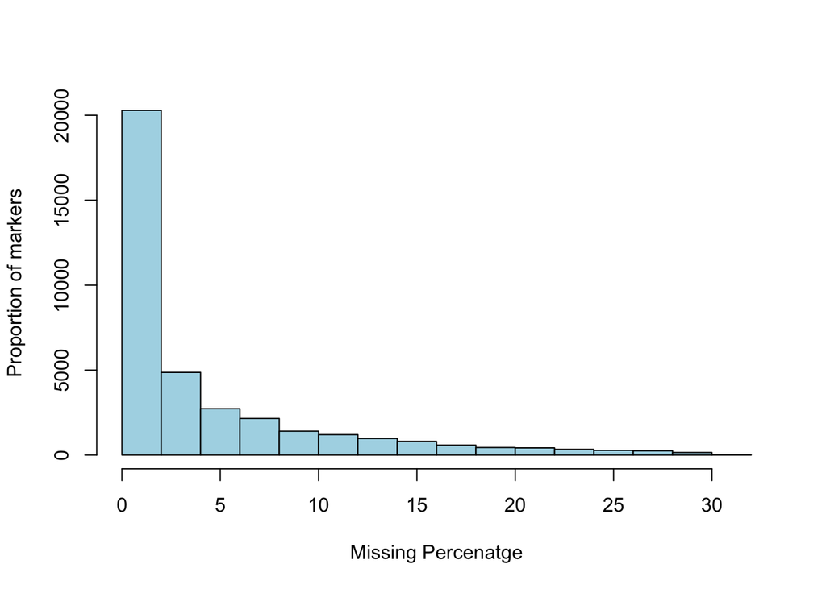

Histogram of missing marker data. X-axis shows missing percenatge and y-axis shows the number of markers that have certain percentage of missing data.

```r
> # Checking missing percentage across snps (SNP call rate)
>   miss_snp<- data.frame(SNPs=apply(Geno,2,function(x){
+     sum(is.na(x))/nrow(Geno)*100
+         }))
> # draw the histogram of missing data
>   hist(miss_snp$SNPs, col = "lightblue", xlab = paste("Missing Percenatge"),
+      ylab="Proportion of markers", main=NULL)
```

```r
> # Markers which have greater than 25% missing data
>   mrt<-which(miss_snp>25)
> # Drop these markers from orginnal file and save it
>   Geno<-Geno[, -c(mrt)]
>   dim(Geno)
```

```
[1]   413 36346
```

```r
> # List of markers that were dropped
>   missing_markers<-subset(miss_snp, SNPs>25)
```

#### 2.1.1.2 b). Genotype Call Rate

- Here we will check for missing data across genotypes/samples.We will again use apply function to sum the NA’s or missing data for each genotype and then dividing it by total number of markers and multiplying this by 100 to get percentage.
- Visulaize the missing data.
- Identify the samples that have more than certain percenatge, for example 15% here.
- And drop these samples from orginal file

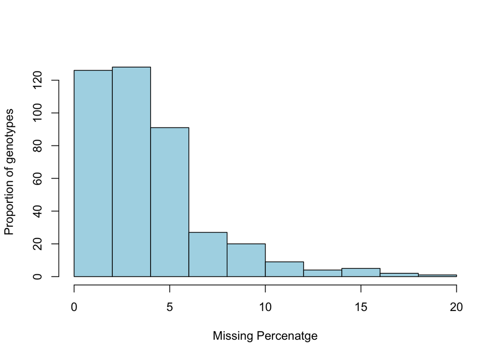

Histogram of missing genotype data. X-axis shows missing percenatge and y-axis shows the proportion of genotypes that have certain percentage of missing data. Most of them have less than 5% missing data, but some of the sampples have missing greater than 5% but less than 20%

```r
> # Checking missing percentage across samples (genotype call rate)
>   miss_geno<- data.frame(Genotypes=apply(Geno,1,function(x){
+    sum(is.na(x))/ncol(Geno)*100
+        }))
>
> # Let us look at the bar plot to get better visualization of missing data across the samples
>   hist(miss_geno$Genotypes, col = "lightblue", ylab="Proportion of genotypes", xlab = "Missing Percenatge",main=NULL)
```

```r
> # Identify the samples that have more than 15% missing data
>   gen<-which(miss_geno>15)
>   Geno<-Geno[-c(gen), ]
>   dim(Geno)
```

```
[1]   409 36346
```

```r
> # List of samples that were dropped
>   missing_genotypes<-subset(miss_geno, Genotypes>15)
>   head(missing_genotypes)
```

```
          Genotypes
NSFTV_72   15.97425
NSFTV_194  16.60705
NSFTV_252  18.38992
NSFTV_260  17.04452
```

### 2.1.2 2. Checking for heterozygosity across samples

- Here we will check for heterozygosity.We will use again use apply function to sum the number heterozygous calls (rember 1 in genotype data means heterozygous), then divide it by number of markers and multiplying this by 100 to get percentage.
  - Visulaize the heterozygote data.
  - Identify the samples that have more than certain percenatge.
  - And drop these samples from orginal file

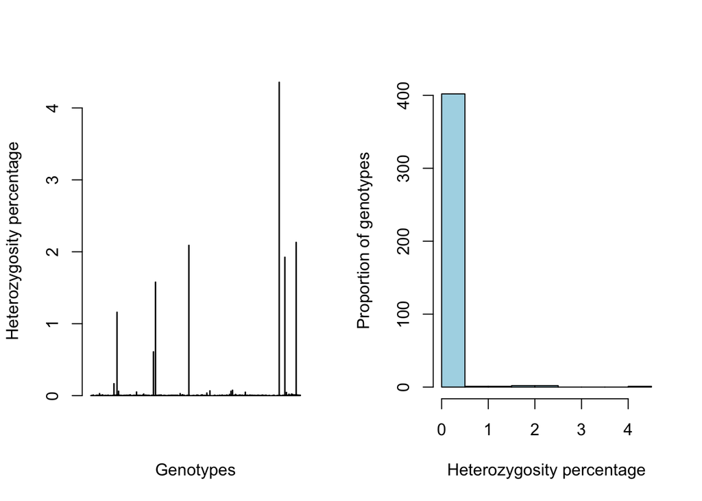

Bar plot and histogram of heterozygosity percentage. In the bar plot X-axis shows genotype names and y-axis shows percentage heterozygosity. Highest heterozygosity is around 4% and few genotyes shows that.In the histogram x-axis shows the heterozygosity percentage and y-axis shows proportion of genotypes having certain heterozygosity

```r
> # get heterozygous percentage
>   htero_geno<-data.frame(htr=apply(Geno,1, function (x){(sum((x==1), na.rm = TRUE)/ncol(Geno)*100)}))
>
> # Visualize using bar and histogram plots
>   par(mfrow=c(1,2))
>   barplot(htero_geno$htr, xlab="Genotypes",
+           ylab="Heterozygosity percentage", col = "darkblue")
>   hist(htero_geno$htr, xlab="Heterozygosity percentage",
+        ylab="Proportion of genotypes", col = "lightblue", main = NULL)
```

```r
> # Here we will not filter for any sample for heterozygosity as it seems reasonable.
>   htrg<-which(htero_geno>4)
>   Geno<-Geno[-c(htrg), ]
> # List of genotypes that were dropped ( one genotype dropped)
>   htrg<-subset(htero_geno, htr>4)
>   dim(Geno)
```

```
[1]   408 36346
```

### 2.1.3 2. Checking marker heterozygosity (HWE)

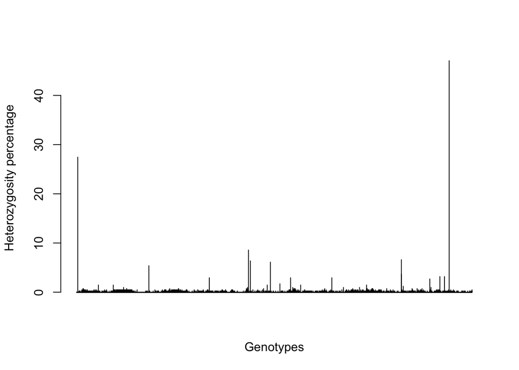

Bar plot showing marker heterozygosity percentage. In the bar plot X-axis shows genotype names and y-axis shows percentage heterozygosity. Note, only two markers have more than 10% of heterozygosity and most of them are below 5%.

```r
> # get heterozygous percentage across the markers
>   htero_mar<-data.frame(htrm=apply(Geno,2, function (x){(sum((x==1),                  na.rm=TRUE)/nrow(Geno)*100)}))
> # Visualize in the bar plot
>   barplot(htero_mar$htrm, xlab="Genotypes",
+         ylab="Heterozygosity percentage", col = "darkblue")
```

```r
> # checking the markers with more than 10 % heterozygosity and drop it.
>   htrm<-which(htero_mar>30)
>   htrm
```

```
[1] 34246
```

```r
>   Geno<-Geno[, -c(htrm)]
>   dim(Geno) # check dimensions of data
```

```
[1]   408 36345
```

```r
> # List the markers that were dropped
>   htrm<-subset(htero_mar, htrm>30)
>   head(htrm)
```

```
               htrm
id12000096 47.05882
```